# QTM 151 - Introduction to Statistical COmputing II

Lecture 23 - Pivot Tables

Danilo Freire

danilo.freire@emory.edu

Emory University

20 November, 2024

# Hello, friends! 😊 How’s everything?

# Brief recap 📚

## Last time we talked about…

- How to work with time series with Python using the `datetime` module
- The [S&P 500](https://en.wikipedia.org/wiki/S%26P_500) and the [Dow Jones Industrial Average](https://en.wikipedia.org/wiki/Dow_Jones_Industrial_Average) stock market indices
- How to visualise the data using `matplotlib`
- How to convert time series to strings using [wildcards](https://en.wikipedia.org/wiki/Wildcard_character) (it’s a bit tricky!). List [here](https://docs.python.org/3/library/datetime.html#strftime-and-strptime-format-codes)
- And finally, we saw how to calculate aggregated statistics

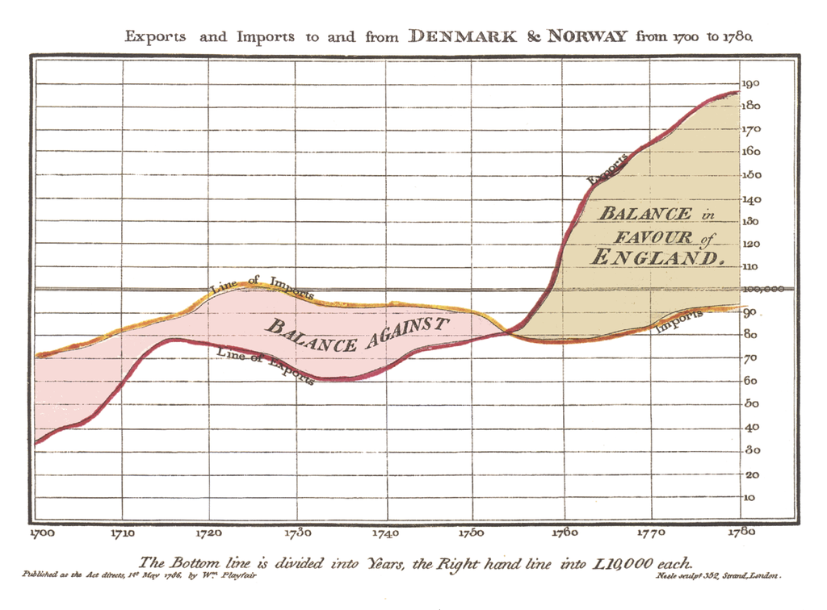

[William Playfair](https://en.wikipedia.org/wiki/William_Playfair) - Export & Import to and from Denmark & Norway from 1700 to 1780 (*Commercial and Political Atlas, 1786*)

# Today’s plan 📊

## Pivot Tables

- Today we will learn more about plotting data
- We will see how to plot multiple variables at once
- We will also learn how to estimate and plot growth rates
- Lastly, we will see how to create pivot tables and change the data structure

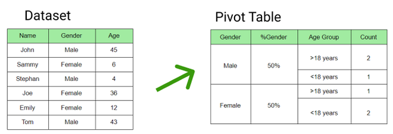

## Import libraries and data 📦

- Let’s start by importing the necessary libraries
- They are the same we used last time (and many other times!)

```python
import pandas as pd
import matplotlib.pyplot as plt
```

- We will also import the data we used last time

```python
financial = pd.read_csv("data_raw/financial.csv")
```

- Let’s take a look at the data

```python
financial.head()
```

|  | date_str | sp500 | djia | date_ex1 | date_ex2 | date_ex3 |
| --- | --- | --- | --- | --- | --- | --- |
| 0 | 4/4/2018 | 2644.69 | 24264.30 | April 04 2018 | Wednesday, 2018-04-04 | 4-Apr-18 |
| 1 | 4/5/2018 | 2662.84 | 24505.22 | April 05 2018 | Thursday, 2018-04-05 | 5-Apr-18 |
| 2 | 4/6/2018 | 2604.47 | 23932.76 | April 06 2018 | Friday, 2018-04-06 | 6-Apr-18 |
| 3 | 4/9/2018 | 2613.16 | 23979.10 | April 09 2018 | Monday, 2018-04-09 | 9-Apr-18 |
| 4 | 4/10/2018 | 2656.87 | 24408.00 | April 10 2018 | Tuesday, 2018-04-10 | 10-Apr-18 |

```python
financial.info()
```

```
<class 'pandas.core.frame.DataFrame'>
RangeIndex: 1305 entries, 0 to 1304
Data columns (total 6 columns):
 #   Column    Non-Null Count  Dtype
---  ------    --------------  -----
 0   date_str  1305 non-null   object
 1   sp500     1260 non-null   float64
 2   djia      1260 non-null   float64
 3   date_ex1  1305 non-null   object
 4   date_ex2  1305 non-null   object
 5   date_ex3  1305 non-null   object
dtypes: float64(2), object(4)
memory usage: 61.3+ KB
```

## Parse and clean data 🧹

- We will parse the date column
- What is parsing, you may ask?
- It’s the process of converting a string into a date
- Our column of interest is `date_str`
- We will convert it to a datetime object
- We will also sort the data by date

```python
financial["date"] = pd.to_datetime(financial["date_str"])
financial = financial.sort_values("date",ascending = True)

financial.dtypes
```

```
date_str            object
sp500              float64
djia               float64
date_ex1            object
date_ex2            object
date_ex3            object
date        datetime64[ns]
dtype: object
```

- What does `[ns]` mean in the `datetime64[ns]` column type?
- It means nanoseconds, which is the smallest unit of time in Python
- It indicates the precision of the date column
- We don’t actually need nanosecond precision, but… well, it doesn’t hurt either! 😅
- We can always change it later if we want to, such as using `pd.to_datetime(financial["date"], unit='s')` to convert it to seconds, or `unit='m'` to convert it to minutes

# Plot multiple variables 📈

## Plotting multiple variables

- Last time, we saw how to plot multiple variables, so let’s refresh our memory
- We will plot the `sp500` and `dji` columns

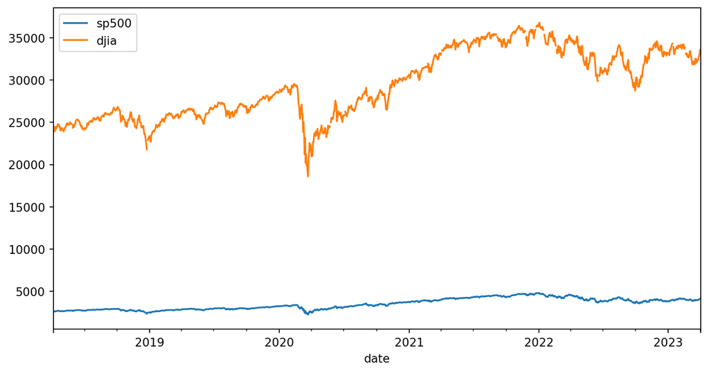

```python
financial[["date","sp500","djia"]].set_index("date").plot()
```

## Plotting multiple variables

- As we also saw last time, the two trends are not immediately comparable because they have different scales
- We can fix this by normalising the data (as we did last time), or by transforming one or both columns
- Last time we saw how to normalise the data by dividing them by the first value

```python
financial["sp500_normalised"] = financial["sp500"] / financial["sp500"].iloc[0]
financial["djia_normalised"] = financial["djia"] / financial["djia"].iloc[0]

# Plot the normalized data
plt.plot("date", "sp500_normalised", data = financial, label = "S&P 500 (Normalised)")
plt.plot("date", "djia_normalised", data = financial, label = "Dow Jones Industrial Average (Normalised)")
plt.xlabel("Time")
plt.ylabel("Normalised Index")
plt.title("S&P 500 vs. Dow Jones Industrial Average (Normalised)")
plt.legend()
plt.show()
```

## Plotting multiple variables

- Let’s see the results

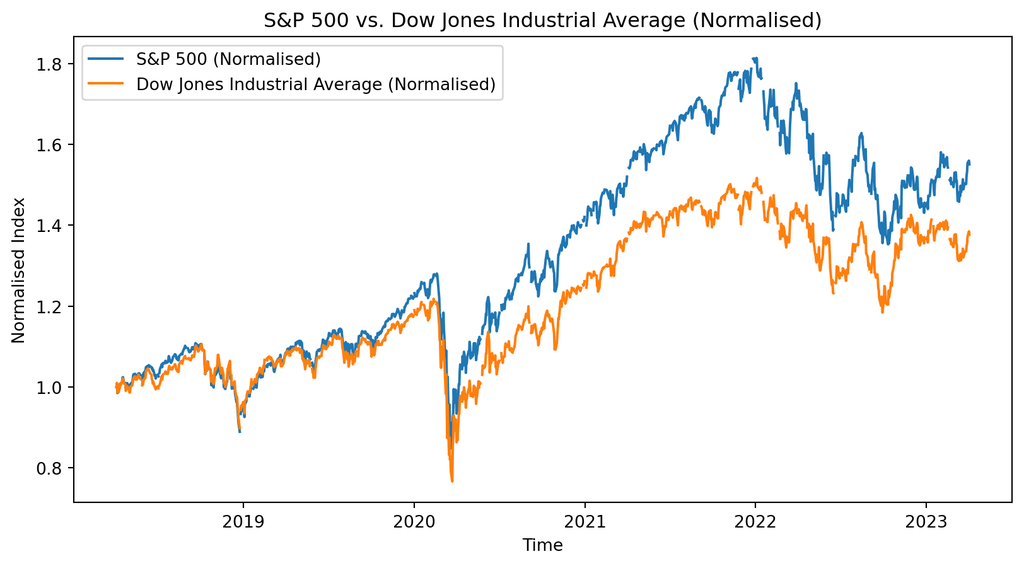

## Plotting multiple variables

- We can also use simple transformations if we have some understanding of the data (which we always should! 😂)
- For example, the `djia` is usually higher than the `sp500`, so we can simply divide the `djia` by 10 to bring the two series closer together

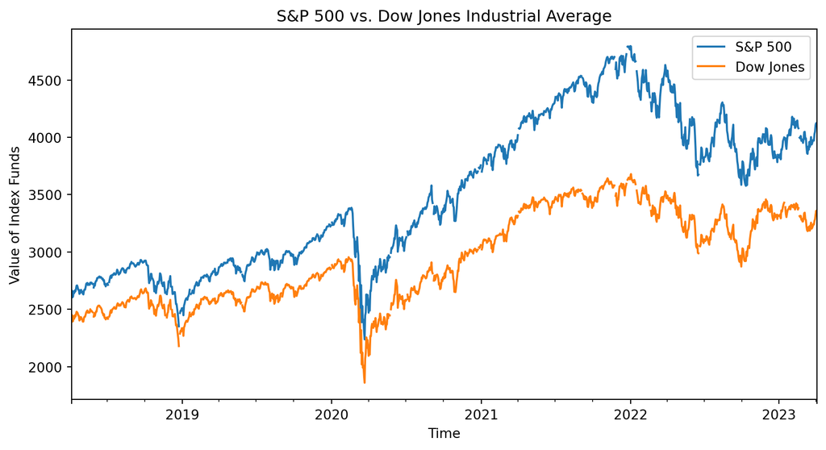

```python
financial['djia_rescale'] = financial['djia']/10

financial[["date","sp500","djia_rescale"]].set_index("date").plot()
plt.xlabel("Time")
plt.ylabel("Value of Index Funds")
plt.legend(["S&P 500","Dow Jones"])
plt.title("S&P 500 vs. Dow Jones Industrial Average")
plt.show()
```

# Time difference/growth rates 📈

## Time difference/growth rates: `diff()`

- We can also calculate the difference between two consecutive values, such as the daily fluctuations of the stock market
- We can do this by using the `diff()` method
- The method simply calculates the difference between the current value and the previous value in the column
- The first value will always be `NaN` because there is no previous value to compare it to
- We must [always ensure that the data are sorted](https://pandas.pydata.org/pandas-docs/stable/reference/api/pandas.DataFrame.sort_values.html) before using the `diff()` method, otherwise the results will be incorrect

```python
financial["diff_sp500"] = financial["sp500"].diff()
financial.head()
```

|  | date_str | sp500 | djia | date_ex1 | date_ex2 | date_ex3 | date | sp500_normalised | djia_normalised | djia_rescale | diff_sp500 |
| --- | --- | --- | --- | --- | --- | --- | --- | --- | --- | --- | --- |
| 0 | 4/4/2018 | 2644.69 | 24264.30 | April 04 2018 | Wednesday, 2018-04-04 | 4-Apr-18 | 2018-04-04 | 1.000000 | 1.000000 | 2426.430 | NaN |
| 1 | 4/5/2018 | 2662.84 | 24505.22 | April 05 2018 | Thursday, 2018-04-05 | 5-Apr-18 | 2018-04-05 | 1.006863 | 1.009929 | 2450.522 | 18.15 |
| 2 | 4/6/2018 | 2604.47 | 23932.76 | April 06 2018 | Friday, 2018-04-06 | 6-Apr-18 | 2018-04-06 | 0.984792 | 0.986336 | 2393.276 | -58.37 |
| 3 | 4/9/2018 | 2613.16 | 23979.10 | April 09 2018 | Monday, 2018-04-09 | 9-Apr-18 | 2018-04-09 | 0.988078 | 0.988246 | 2397.910 | 8.69 |
| 4 | 4/10/2018 | 2656.87 | 24408.00 | April 10 2018 | Tuesday, 2018-04-10 | 10-Apr-18 | 2018-04-10 | 1.004605 | 1.005922 | 2440.800 | 43.71 |

## Time difference/growth rates

- We can plot the differences in both the `sp500` and `djia` columns to see the daily fluctuations

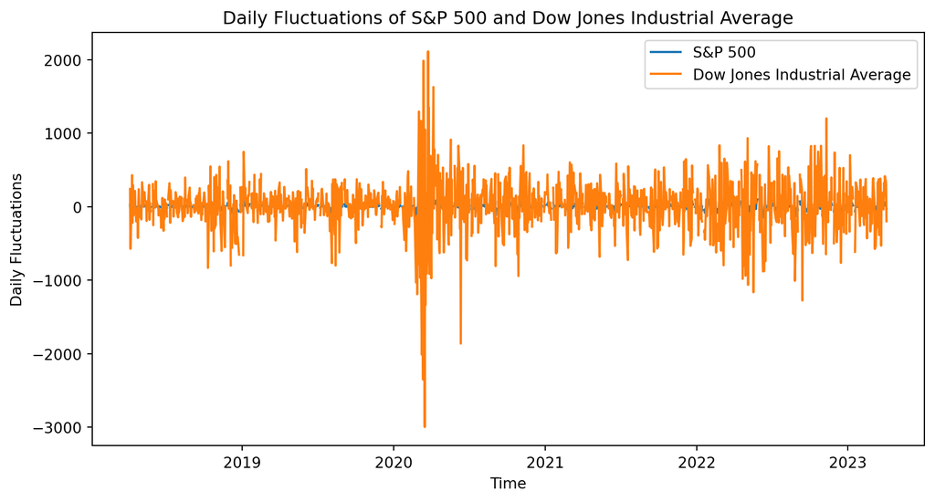

```python
financial["diff_djia"] = financial["djia"].diff()

plt.plot("date", "diff_sp500", data = financial, label = "S&P 500")
plt.plot("date", "diff_djia", data = financial, label = "Dow Jones Industrial Average")
plt.xlabel("Time")
plt.ylabel("Daily Fluctuations")
plt.title("Daily Fluctuations of S&P 500 and Dow Jones Industrial Average")
plt.legend()
plt.show()
```

## Hmmm, that’s still not very informative… 🤔

### Compute lagged differences and growth rates

- As you may have guessed, the plot is still a little messy because of the difference in scales
- We can fix this using lagged differences
- We can calculate the growth rate by dividing the difference by the previous value
- First, we will create a new column with the lagged values, then calculate the growth rate

```python
financial["lag_sp500"] = financial["sp500"].shift(1)

# Convert into percentage
financial["growth_sp500"] = (financial["diff_sp500"]/financial["lag_sp500"]) * 100

financial.head()
```

|  | date_str | sp500 | djia | date_ex1 | date_ex2 | date_ex3 | date | sp500_normalised | djia_normalised | djia_rescale | diff_sp500 | diff_djia | lag_sp500 | growth_sp500 |
| --- | --- | --- | --- | --- | --- | --- | --- | --- | --- | --- | --- | --- | --- | --- |
| 0 | 4/4/2018 | 2644.69 | 24264.30 | April 04 2018 | Wednesday, 2018-04-04 | 4-Apr-18 | 2018-04-04 | 1.000000 | 1.000000 | 2426.430 | NaN | NaN | NaN | NaN |
| 1 | 4/5/2018 | 2662.84 | 24505.22 | April 05 2018 | Thursday, 2018-04-05 | 5-Apr-18 | 2018-04-05 | 1.006863 | 1.009929 | 2450.522 | 18.15 | 240.92 | 2644.69 | 0.686281 |
| 2 | 4/6/2018 | 2604.47 | 23932.76 | April 06 2018 | Friday, 2018-04-06 | 6-Apr-18 | 2018-04-06 | 0.984792 | 0.986336 | 2393.276 | -58.37 | -572.46 | 2662.84 | -2.192021 |
| 3 | 4/9/2018 | 2613.16 | 23979.10 | April 09 2018 | Monday, 2018-04-09 | 9-Apr-18 | 2018-04-09 | 0.988078 | 0.988246 | 2397.910 | 8.69 | 46.34 | 2604.47 | 0.333657 |
| 4 | 4/10/2018 | 2656.87 | 24408.00 | April 10 2018 | Tuesday, 2018-04-10 | 10-Apr-18 | 2018-04-10 | 1.004605 | 1.005922 | 2440.800 | 43.71 | 428.90 | 2613.16 | 1.672687 |

## Let’s plot the graph

- That looks much better! 😊
- We can see the daily fluctuations in the S&P 500 index in percentage terms, which is indeed more informative

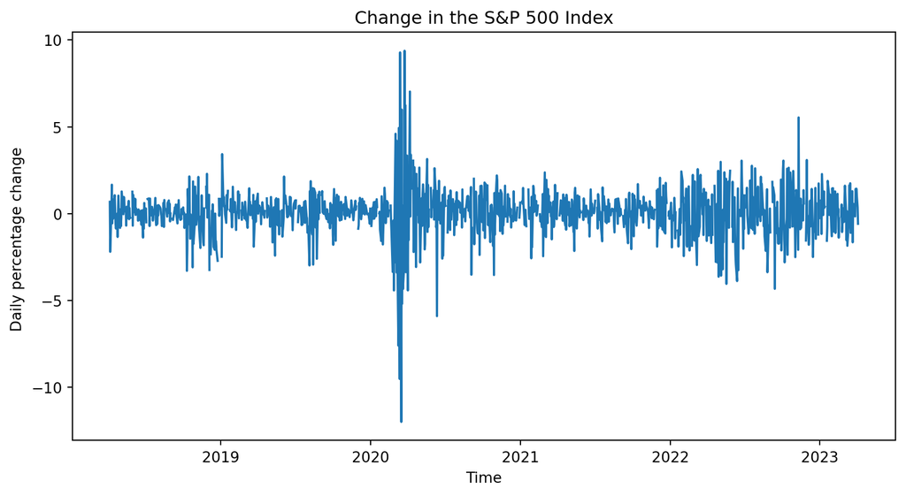

```python
plt.plot("date", "growth_sp500",
          data = financial)
plt.xlabel("Time")
plt.ylabel("Daily percentage change ")
plt.title("Change in the S&P 500 Index")
plt.show()
```

## Try it yourself! 🧠

- Now it’s your turn!
- Compute a column with the growth of the Dow Jones
- Plot the growth of the S&P 500 and Dow Jones in a single plot
- Appendix 01

# Subsetting with time data 📉

## Subsetting with time data

- Do you remember our old friend `query()`?
- We can use it again here! 😊
- Since the `date` column has a time format, Python will interpret `2019-01-01` as a date inside the query command
- We can use boolean operators to subset the data
- Note: remember that you have to use single quotations for `.query()`

```python
subset_before  = financial.query('date <= "2019-01-01"')
subset_after   = financial.query('date >= "2020-01-01"')

max(subset_before['date'])
```

```
Timestamp('2019-01-01 00:00:00')
```

```python
max(subset_after['date'])
```

```
Timestamp('2023-04-04 00:00:00')
```

## Subsetting with time data

- We can also subset between two dates

```python
subset_between = financial.query('date.between("2020-03-01","2020-05-01")')
subset_between.iloc[:, :6].head(3)
```

|  | date_str | sp500 | djia | date_ex1 | date_ex2 | date_ex3 |
| --- | --- | --- | --- | --- | --- | --- |
| 498 | 3/2/2020 | 3090.23 | 26703.32 | March 02 2020 | Monday, 2020-03-02 | 2-Mar-20 |
| 499 | 3/3/2020 | 3003.37 | 25917.41 | March 03 2020 | Tuesday, 2020-03-03 | 3-Mar-20 |
| 500 | 3/4/2020 | 3130.12 | 27090.86 | March 04 2020 | Wednesday, 2020-03-04 | 4-Mar-20 |

```python
subset_between.iloc[:, :6].tail(3)
```

|  | date_str | sp500 | djia | date_ex1 | date_ex2 | date_ex3 |
| --- | --- | --- | --- | --- | --- | --- |
| 540 | 4/29/2020 | 2939.51 | 24633.86 | April 29 2020 | Wednesday, 2020-04-29 | 29-Apr-20 |
| 541 | 4/30/2020 | 2912.43 | 24345.72 | April 30 2020 | Thursday, 2020-04-30 | 30-Apr-20 |
| 542 | 5/1/2020 | 2830.71 | 23723.69 | May 01 2020 | Friday, 2020-05-01 | 1-May-20 |

## Subsetting with time data

```python
financial["bool_period"]  = financial["date"].between("2020-03-01","2020-05-01")
financial["bool_example"] = financial["growth_sp500"] > 5

# Create a line plot
plt.plot("date", "growth_sp500", data = financial)
plt.xlabel("Time")
plt.ylabel("Daily percentage change ")
plt.title("The S&P 500 during the start of COVID")

# Add a shaded region wth a rectangle
# "x" is the x-coordinates, "y1" and "y2" are the lower
# and upper bounds of the rectangle. We can set this
# to be the minimum and meximum of the outcome.
# we use "where" to test a logical condition

vec_y = financial["growth_sp500"]
plt.fill_between(x= financial["date"],
                 y1 = vec_y.min(),
                 y2 = vec_y.max(),
                 where = financial["bool_period"],
                 alpha = 0.2,color = "red")

plt.show()
```

## Let’s see the graph

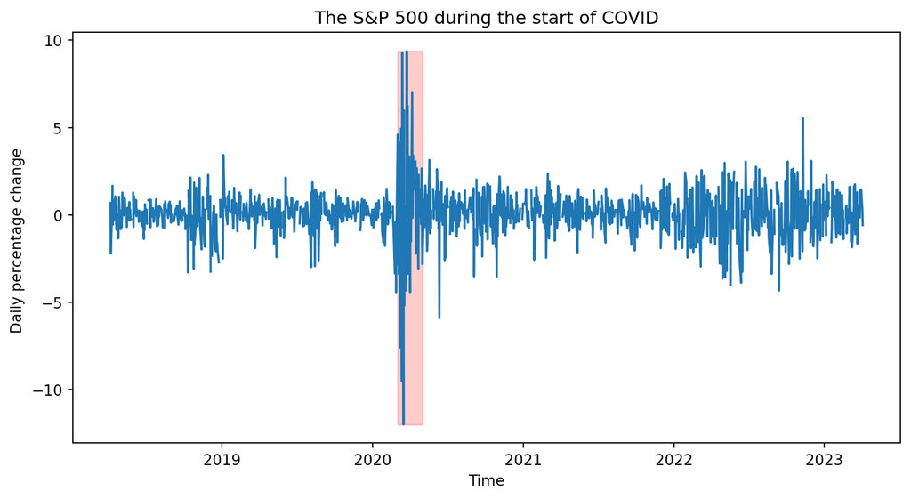

## Try it yourself! 🧠

- Now it’s your turn again!
- Generate a plot of the daily growth of the Dow Jones
- Highlight regions where there was growth higher than 4% or below -4%
- Appendix 02

# Wide and long data formats 📊

## Wide and long data formats

- Data can come in a wide variety of formats
- Few rows, multiple columns (wide)
- Stacked rows, few columns (long)
- The information is the same, but the structure is different

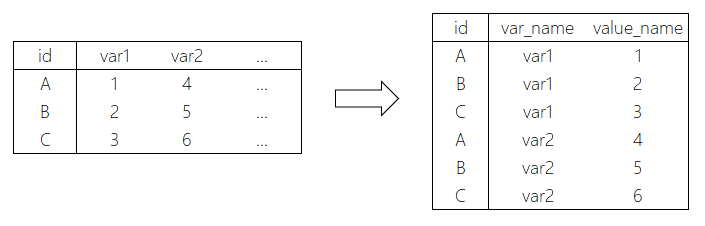

- We can convert data from wide to long format using the `melt()` function
- The `melt()` function takes the following arguments:
  - `id_vars`: the columns to keep as is
  - `value_vars`: the columns to melt
  - `var_name`: the name of the new column with the variable names
  - `value_name`: the name of the new column with the values

## Wide and long data formats

- Let’s see an example

```python
financial_long = pd.melt(financial,
                         var_name = "portfolio_type", # variable name
                         value_name = "portfolio_value", # value name
                         id_vars='date', # keep the date column
                         value_vars=['sp500','djia']) # melt the sp500 and djia columns
```

- And now we have the data in long format:

```python
financial_long.sort_values(by='date').head()
```

|  | date | portfolio_type | portfolio_value |
| --- | --- | --- | --- |
| 0 | 2018-04-04 | sp500 | 2644.69 |
| 1305 | 2018-04-04 | djia | 24264.30 |
| 1306 | 2018-04-05 | djia | 24505.22 |
| 1 | 2018-04-05 | sp500 | 2662.84 |
| 2 | 2018-04-06 | sp500 | 2604.47 |

## Long data format

- We can also convert the data back to wide format using the `pivot()` function
- The `pivot()` function takes the following arguments:
  - `index`: the column to keep as is
  - `columns`: the column to pivot
  - `values`: the column with the values

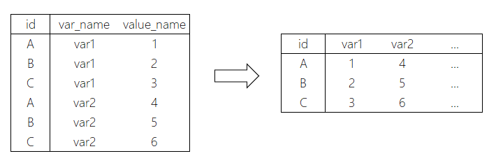

```python
financial_wide = (pd.pivot(financial_long,
                           index = 'date',
                           columns = 'portfolio_type',
                           values =  'portfolio_value'))

financial_wide.head()
```

| portfolio_type date | djia | sp500 |
| --- | --- | --- |
| 2018-04-04 | 24264.30 | 2644.69 |
| 2018-04-05 | 24505.22 | 2662.84 |
| 2018-04-06 | 23932.76 | 2604.47 |
| 2018-04-09 | 23979.10 | 2613.16 |
| 2018-04-10 | 24408.00 | 2656.87 |

- If you also want the index to be part of the dataset add `.reset_index()` to the end of the previous command

## Try it yourself! 🧠

- Convert the `growth_sp500` and `growth_djia` to long format
- Appendix 03

# That’s all for today! 🎉

# Thank you for your attention and see you soon! 🙏

## Appendix 01: Solution

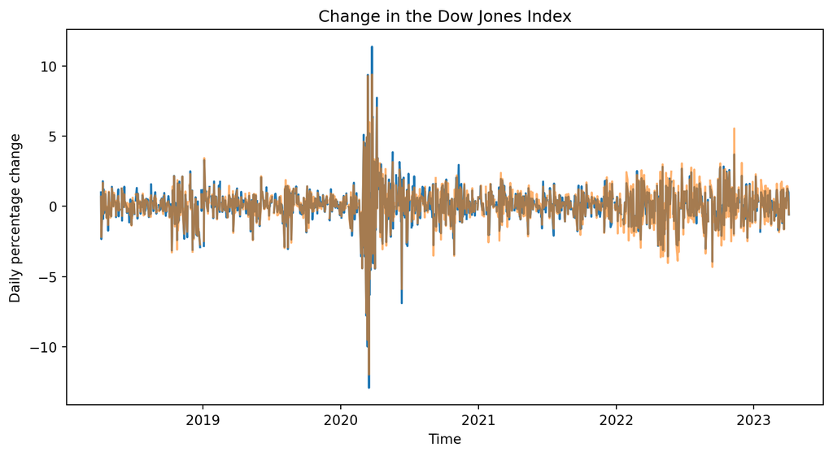

```python
financial["diff_djia"] = financial["djia"].diff()
financial["lag_djia"]  = financial["djia"].shift(1)
financial["growth_djia"] = (financial["diff_djia"] / financial["lag_djia"])*100

# Method 1: Adding multiple lines with "plt.plot()"
# you can make a plot transparent by adding an alpha parameter (between 0 and 1)

plt.plot("date","growth_djia",data= financial)
plt.plot("date","growth_sp500",data= financial,alpha = 0.6)
plt.xlabel("Time")
plt.ylabel("Daily percentage change")
plt.title("Change in the Dow Jones Index")
plt.show()
```

Back to Exercise 01

## Appendix 01: Solution

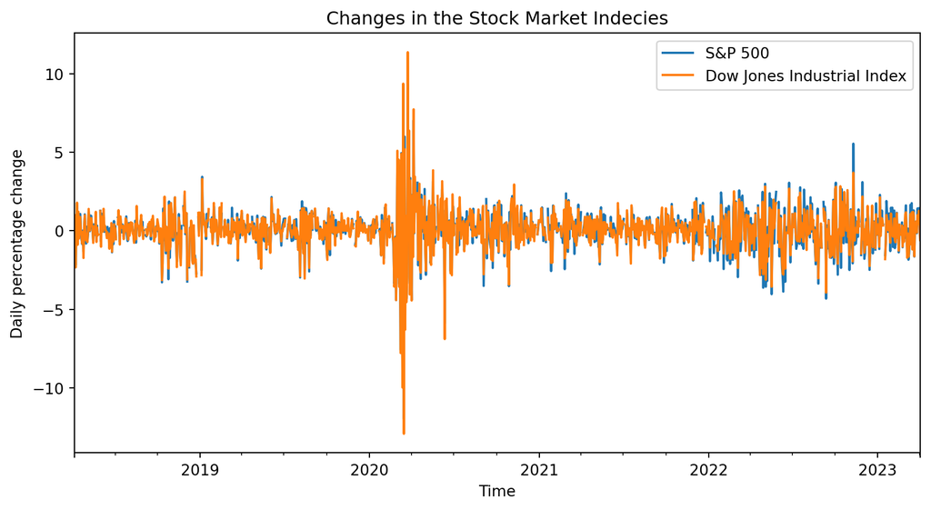

```python
# Method 2: A single line with ".plot()" but setting the "x-axis"
# with ".set_index()"
financial[["date","growth_sp500","growth_djia"]].set_index("date").plot()
plt.xlabel("Time")
plt.ylabel("Daily percentage change")
plt.title("Changes in the Stock Market Indecies")
plt.legend(["S&P 500", "Dow Jones Industrial Index"])
plt.show()
```

Back to Exercise 01

## Appendix 02: Solution

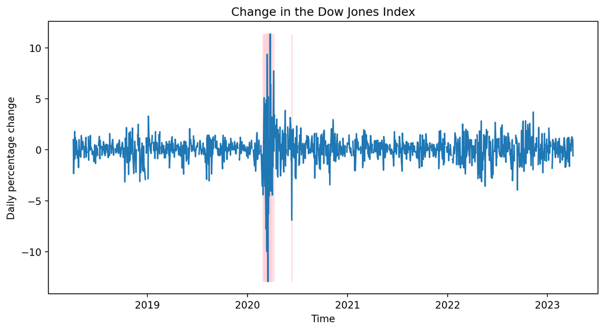

```python
plt.plot("date","growth_djia",data= financial)
plt.xlabel("Time")
plt.ylabel("Daily percentage change")
plt.title("Change in the Dow Jones Index")

financial["bool_djia"] = (financial["growth_djia"] > 4) | (financial["growth_djia"] < -4)
vec_y = financial["growth_djia"]
plt.fill_between(x = financial["date"],
                 y1 = vec_y.min(),
                 y2 = vec_y.max(),
                 where = financial["bool_djia"],
                 alpha = 0.7,color="pink")
```

Back to Exercise 02

## Appendix 03: Solution

```python
financial_long = pd.melt(financial,
                         var_name = "portfolio_type",
                         value_name = "portfolio_value",
                         id_vars='date',
                         value_vars=['growth_sp500','growth_djia'])

financial_long.sort_values(by='date').head()
```

|  | date | portfolio_type | portfolio_value |
| --- | --- | --- | --- |
| 0 | 2018-04-04 | growth_sp500 | NaN |
| 1305 | 2018-04-04 | growth_djia | NaN |
| 1306 | 2018-04-05 | growth_djia | 0.992899 |
| 1 | 2018-04-05 | growth_sp500 | 0.686281 |
| 2 | 2018-04-06 | growth_sp500 | -2.192021 |

Back to Exercise 03

[Pivot Tables](https://raw.githack.com/danilofreire/qtm151/main/lectures/lecture-23/23-pivot-tables.html)